# Tutorial 8: Random intercept models

Forschungspraktikum I und II: Vergleichende Sozialforschung mit Mehrebenenmodellen in R

Dr. Christian Czymara (Sociology with Focus on Quantitative Methods for Social Research, Goethe University Frankfurt)

In this exercise, we will use hierarchical linear models to examine support for a basic income scheme, using data from the eighth wave of the ESS (2016/17).

## 1. Importing data

Import ESS8_edit.dta and assign it to object `ESS16`.

```r
setwd("C:/Users/czymara.local/Nextcloud/teaching/FoP HLM/_R/08_hierarchical_linear_models")
```

[output not shown]

```r
library(haven)

ESS16 <- read_dta("ESS8_edit.dta")
```

## 2. Random intercept

### a) Null model and ICC

Support for a basic income scheme is measured by the variable `basinc` (assumed continuous). First, we want to know how much public opinion on a basic income scheme differs across countries. The null model includes a random intercept at the country-level but no explanatory variables:

$$basinc_{ij}=\beta_{0}+u_{0j}+e_{ij}$$

Run this model using the `lmer()` function of the `lme4` package. Then calculate the share of variance between countries ($\sigma_u^2$) from the total variance of `basinc`. What does the value tell us?

```r
# install and load lme4
if(!require(lme4)){
    install.packages("lme4")
    library(lme4)
  }

m_0 <- lmer(basinc ~ 1 + (1 | cntry),
            data = ESS16)

summary(m_0)
```

```
## Linear mixed model fit by REML ['lmerMod']
## Formula: basinc ~ 1 + (1 | cntry)
##    Data: ESS16
##
## REML criterion at convergence: 61388.4
##
## Scaled residuals:
##      Min       1Q   Median       3Q      Max
## -2.53385 -0.62972 -0.00497  0.66476  2.42606
##
## Random effects:
##  Groups   Name        Variance Std.Dev.
##  cntry    (Intercept) 0.04178  0.2044
##  Residual             0.62547  0.7909
## Number of obs: 25880, groups:  cntry, 19
##
## Fixed effects:
##             Estimate Std. Error t value
## (Intercept)  2.50252    0.04717   53.05
```

```r
# ICC
0.04178/(0.04178+0.62547)
```

```
## [1] 0.06261521
```

```r
# without copy pasting
VarCorr(m_0)$cntry[1] # cntry random effect (between country variance)
```

```
## [1] 0.04178462
```

```r
sigma(m_0)^2 # variance of residuals (within country variance)
```

```
## [1] 0.6254668
```

```r
VarCorr(m_0)$cntry[1]/(VarCorr(m_0)$cntry[1] + sigma(m_0)^2)
```

```
## [1] 0.062622
```

```r
# or using the ICC function

# install and load performance
if(!require(performance)){
    install.packages("performance")
    library(performance)
  }

icc(m_0)
```

```
## # Intraclass Correlation Coefficient
##
##      Adjusted ICC: 0.063
##   Conditional ICC: 0.063
```

### b) Random effects

Random intercepts measure the spread of Y around the grand intercept. To understand the logic of random effects, compare their estimates and the country means. Use the `ranef()` function to access the random effects for each country (that is, their conditional modes to be precise). Add these values to the grand intercept of the null model. Then compare to the mean of `basinc` for each country.

```r
randomEffects <- m_0@beta + ranef(m_0)$cntry

countryMeans <- aggregate(basinc ~ cntry, ESS16, mean)

round(randomEffects, 1) == round(countryMeans$basinc, 1) # taking into account rounding errors
```

```
##    (Intercept)
## AT        TRUE
## BE        TRUE
## CZ        TRUE
## DE        TRUE
## EE        TRUE
## ES        TRUE
## FI        TRUE
## FR        TRUE
## GB        TRUE
## HU        TRUE
## IE        TRUE
## IT        TRUE
## LT        TRUE
## NL        TRUE
## NO        TRUE
## PL        TRUE
## PT        TRUE
## SE        TRUE
## SI        TRUE
```

## 3. Economic wealth and basic income scheme support

### a) Descriptive country comparison

Plot the relationship between average basic income scheme support and wealth measured by the Gross Domestic Product (GDP) per head (`gdppc`).

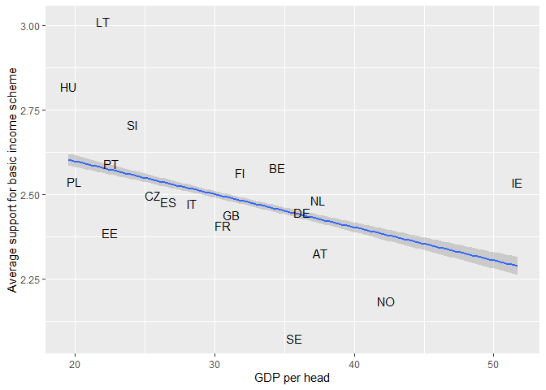

```r
library(tidyverse)

ESS16 %>%
  ggplot(aes(x = gdppc,
             y = basinc,
             label = cntry)) +
  geom_smooth(method = "lm") +
  stat_summary(fun = mean,
               geom = "text") +
  ylab("Average support for basic income scheme") +
  xlab("GDP per head")
```

### b) Country-level variables

Does the association of GDP per head and individual basic income scheme support hold when differences in national income inequality are taken into account? Add the two country-level variables GPD per head and Gini index (this [index measures inequality](https://en.wikipedia.org/wiki/Gini_coefficient) with 0 meaning complete income equality and 100 percent meaning complete income inequality).). Estimate the following model:

$$basinc_{ij}=\beta_{0}+\gamma_{1}gdppc_{j}+\gamma_{2}c\_gini\_2016_{j}+u_{0j}+e_{ij}$$

```r
m_country <- lmer(basinc ~ gdppc + c_gini_2016 + (1 | cntry), data = ESS16)

summary(m_country)
```

```
## Linear mixed model fit by REML ['lmerMod']
## Formula: basinc ~ gdppc + c_gini_2016 + (1 | cntry)
##    Data: ESS16
##
## REML criterion at convergence: 61398.3
##
## Scaled residuals:
##      Min       1Q   Median       3Q      Max
## -2.53523 -0.62998 -0.00635  0.66333  2.42595
##
## Random effects:
##  Groups   Name        Variance Std.Dev.
##  cntry    (Intercept) 0.03412  0.1847
##  Residual             0.62547  0.7909
## Number of obs: 25880, groups:  cntry, 19
##
## Fixed effects:
##              Estimate Std. Error t value
## (Intercept)  2.573070   0.471173   5.461
## gdppc       -0.010837   0.005575  -1.944
## c_gini_2016  0.008893   0.012962   0.686
##
## Correlation of Fixed Effects:
##             (Intr) gdppc
## gdppc       -0.653
## c_gini_2016 -0.937  0.362
```

### c) Explained between country variance

How much between country variance can be explained by the two country-level variables (compared to the null model)?

```r
# Calculate manually
1-(0.03412/0.04178)
```

```
## [1] 0.1833413
```

```r
# Use stored information
1-(VarCorr(m_country)$cntry[1]/VarCorr(m_0)$cntry[1])
```

```
## [1] 0.183347
```

## 3. Composition effects

### a) Individual-level variables

Add the socio-economic variables income, education, and labor market status as controls (the *_2 etc. variables are the respective categories):

$$basinc_{ij}=\beta_{0}+\gamma_{1}gdppc_{j}+\gamma_{2}c\_gini\_2016_{j}+\beta_{1}hinctnt_{ij}+\beta_{2}res\_educ\_2_{ij}+\beta_{3}res\_educ\_3_{ij}+\beta_{4}res\_educ\_4_{ij}+\beta_{5}laborstat\_2_{ij}+\beta_{6}laborstat\_3_{ij}+u_{0j}+e_{ij}$$

Is the relationship between basic income scheme support and GDP/head driven by compositional differences between countries?

```r
m_ind <- lmer(basinc ~ gdppc + c_gini_2016 + hinctnta + factor(res_educ) + factor(laborstat) + (1 | cntry), data = ESS16)

summary(m_ind)
```

```
## Linear mixed model fit by REML ['lmerMod']
## Formula: basinc ~ gdppc + c_gini_2016 + hinctnta + factor(res_educ) +
##     factor(laborstat) + (1 | cntry)
##    Data: ESS16
##
## REML criterion at convergence: 61263.8
##
## Scaled residuals:
##      Min       1Q   Median       3Q      Max
## -2.79392 -0.64094  0.07418  0.68485  2.61287
##
## Random effects:
##  Groups   Name        Variance Std.Dev.
##  cntry    (Intercept) 0.03436  0.1854
##  Residual             0.62129  0.7882
## Number of obs: 25880, groups:  cntry, 19
##
## Fixed effects:
##                     Estimate Std. Error t value
## (Intercept)         2.752661   0.473299   5.816
## gdppc              -0.011062   0.005595  -1.977
## c_gini_2016         0.008026   0.013008   0.617
## hinctnta           -0.020603   0.002047 -10.066
## factor(res_educ)2  -0.055508   0.016459  -3.372
## factor(res_educ)3  -0.038719   0.013292  -2.913
## factor(res_educ)4  -0.027414   0.015572  -1.761
## factor(laborstat)2  0.099685   0.017707   5.630
## factor(laborstat)3 -0.048607   0.011522  -4.218
##
## Correlation of Fixed Effects:
##             (Intr) gdppc  c__201 hnctnt fc(_)2 fc(_)3 fc(_)4 fct()2
## gdppc       -0.653
## c_gini_2016 -0.936  0.362
## hinctnta    -0.037  0.005  0.004
## fctr(rs_d)2 -0.012 -0.004 -0.002  0.111
## fctr(rs_d)3 -0.036  0.014  0.011  0.224  0.454
## fctr(rs_d)4 -0.018  0.007 -0.005  0.280  0.390  0.542
## fctr(lbrs)2 -0.008 -0.003  0.001  0.151  0.006 -0.059 -0.127
## fctr(lbrs)3 -0.018 -0.001  0.005  0.277 -0.004 -0.025 -0.184  0.310
```

### b) Results table

Create a table that shows the results of the null model, the model with country-level variables, and the last model. For better comparison, show the standardized coefficients.

```r
library(sjPlot)

tab_model(m_0, m_country, m_ind,
          title = "Support for basic income scheme",
          dv.labels = c("Null model", "Country variables", "Individual Variables"),
          show.std = T,
          show.est = F)
```

Support for basic income scheme

|  | Null model |  |  | Country variables |  |  | Individual Variables |  |  |
| --- | --- | --- | --- | --- | --- | --- | --- | --- | --- |
| Predictors | std. Beta | standardized CI | p | std. Beta | standardized CI | p | std. Beta | standardized CI | p |
| (Intercept) | 0.02 | -0.09 – 0.14 | **<0.001** | 0.01 | -0.10 – 0.11 | **<0.001** | 0.05 | -0.06 – 0.16 | **<0.001** |
| GDP per head(PPP,1000$) |  |  |  | -0.11 | -0.22 – 0.00 | 0.052 | -0.11 | -0.22 – -0.00 | **0.048** |
| [COUNTRY]Gini coefficient of equivalised disposable income 2016 |  |  |  | 0.04 | -0.07 – 0.14 | 0.493 | 0.03 | -0.07 – 0.14 | 0.537 |
| Household’s total net income,all sources |  |  |  |  |  |  | -0.07 | -0.08 – -0.06 | **<0.001** |
| factor(res_educ)2 |  |  |  |  |  |  | -0.07 | -0.11 – -0.03 | **0.001** |
| factor(res_educ)3 |  |  |  |  |  |  | -0.05 | -0.08 – -0.02 | **0.004** |
| factor(res_educ)4 |  |  |  |  |  |  | -0.03 | -0.07 – 0.00 | 0.078 |
| factor(laborstat)2 |  |  |  |  |  |  | 0.12 | 0.08 – 0.17 | **<0.001** |
| factor(laborstat)3 |  |  |  |  |  |  | -0.06 | -0.09 – -0.03 | **<0.001** |
| Random Effects |  |  |  |  |  |  |  |  |  |
| σ<sup>2</sup> | 0.63 |  |  | 0.63 |  |  | 0.62 |  |  |
| τ<sub>00</sub> | 0.04 <sub>cntry</sub> |  |  | 0.03 <sub>cntry</sub> |  |  | 0.03 <sub>cntry</sub> |  |  |
| ICC | 0.06 |  |  | 0.05 |  |  | 0.05 |  |  |
| N | 19 <sub>cntry</sub> |  |  | 19 <sub>cntry</sub> |  |  | 19 <sub>cntry</sub> |  |  |
| Observations | 25880 |  |  | 25880 |  |  | 25880 |  |  |
| Marginal R<sup>2</sup> / Conditional R<sup>2</sup> | 0.000 / 0.063 |  |  | 0.016 / 0.067 |  |  | 0.022 / 0.074 |  |  |

### c) Model fit

Use the `lrtest()` function of the `lmtest` package to perform a Likelihood-Ratio-test (LR-test) and test whether adding the individual-level variables leads to an increased model fit compared to the model of including only country-level variables.

```r
if(!require(lmtest)){
    install.packages("lmtest")
    library(lmtest)
  }

lrtest(m_country, m_ind)
```

```
## Likelihood ratio test
##
## Model 1: basinc ~ gdppc + c_gini_2016 + (1 | cntry)
## Model 2: basinc ~ gdppc + c_gini_2016 + hinctnta + factor(res_educ) +
##     factor(laborstat) + (1 | cntry)
##   #Df LogLik Df  Chisq Pr(>Chisq)
## 1   5 -30699
## 2  11 -30632  6 134.55  < 2.2e-16 ***
## ---
## Signif. codes:  0 '***' 0.001 '**' 0.01 '*' 0.05 '.' 0.1 ' ' 1
```